# Module 6 Report

stop_drop_and_code

2022-11-06

## Wing Shape Evolution in the Lepidoptera

### Introduction

The Lepidoptera refers to the order of insects comprising of butterflies, moths, and skippers. Each of these organisms have two forewings and two hindwings, covered in scales. While there have been many papers written on the Lepidoptera, there is still much to learn about wing shape evolution in this group. Le Roy, Debat, and Llaurens (2019) explains that although correlations between wing shape variation and ecological factors have been estalished, the underlying selective pressures are still not clear. In addition to this, H. Owens et al. (2020) reports that forewing and hindwing evolution occurs independently, however, other studies like Chazot et al. (2016) report that there is a strong correlation between forewing and hindwing shapes (at least in the morpho group of butterflies). Due to this wide range of reports from different researchers, it is clear that more analysis needs to be done to better understand wing development in the Lepidoptera. This project aims to elucidate whether or not fore- and hindwings vary in evolutionary rates, whether the evolvability of fore- and hindwings varies significantly among major lineages of moths and butterflies, and whether fore- and hindwing shape is correlated.

Love the intro!

### Methods

*Are the rates of wing-shape evolution different between the hind- and forewing? By how much?*  
To analyze the rate of wing-shape evolution in the Lepidoptera, photos of specimens across the entire order were first compiled using images cataloged in the Global Biodiversity Information Facility database. Approximately 200 species were included in this report. Wing shape was then digitized with the image analysis program FIJI.  
Outline-based shape analysis was performed using an elliptical Fourier transformation. To account for arbitrary differences in wing size due to the orientation of the original photos and the lack of a scale bar in some cases, a generalized Procrustes transformation was first applied. With this outline data, Principal Components Analysis was used to quantify the amount of variance observed due to a particular principal component (PC). These operations were run with the R package Momocs. When outlines were separately analyzed according to whether they were fore- or hind-wing, separate PC scores were obtained and compared.

*Have major lineages of the Lepidoptera undergone significant shifts in evolutionary rate?*  
The phylogenetic tree used in the analysis of this report was created by Kawahara et al. (2019). To compare the rates of evolution throughout major Lepidoptera lineages, the non-censored test by O’Meara et al. (2006) was used within the R package phytools. After eliminating species from the original phylogenetic tree that were not included in this report, evolutionary rates were calculated for the first and second PCs in fore- and hind-wings  
Next, phylogenetic ridge regression by Kratsch and McHardy (2014) was performed from the R package RRphylo to determine whether any rate shifts were to a slower or faster rate. Once clades were identified to have undergone a rate shift, the lineage name was identified and the scale of the shift was plotted on the phylogenetic tree.  
*Are hind- and forewing shapes correlated?*  
Correlation between hind- and fore-wing shape evolution was analyzed with Phylogenetic Independent Contrasts (PIC) analysis. Hind- and fore-wing PC vectors were regressed against one another for PC1 and PC2 and a linear model was fitted to the data.

This methods section is great!

### Results

Bummer! You didn’t include the data! I put the directory in your repo so this, and everything else, will run. The tree file, image metadata and taxon names, too!

```r
grade <- 75

grade <- grade-4
```

#### PCA Analysis

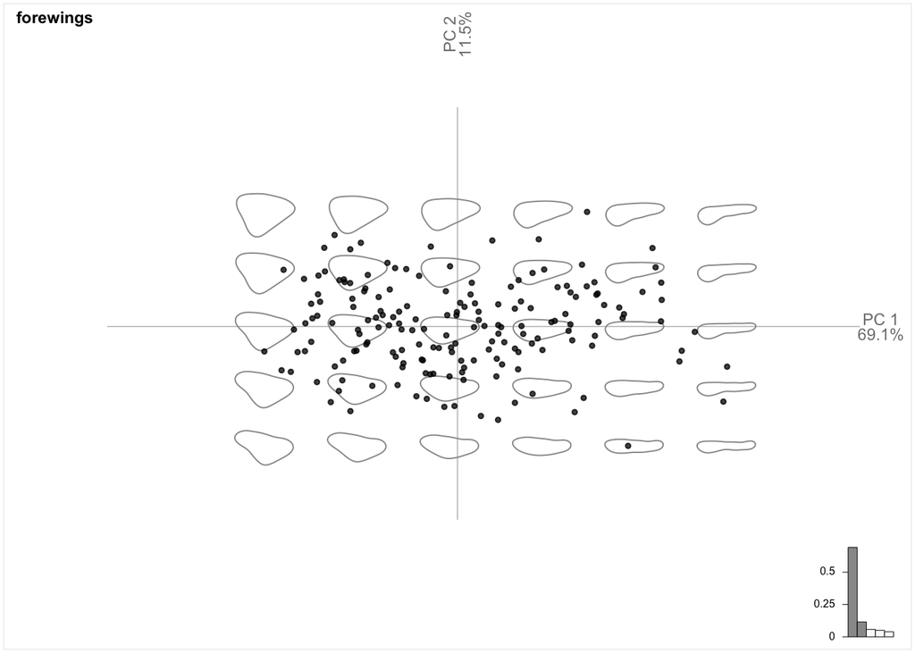

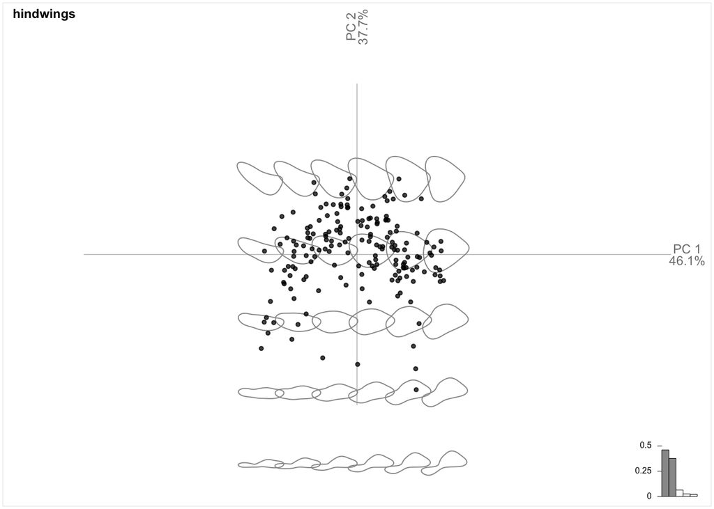

#### Comparative Analysis

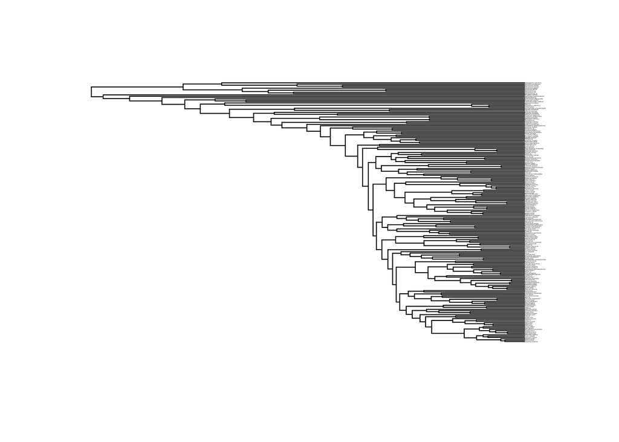

```r
lep.tree <- ape::read.tree("lep_tree2.tre") %>% ladderize()
lep.tree$tip.label <- gsub("_"," ",lep.tree$tip.label)
plot(lep.tree,cex=0.1)
```

#### Evolutionary Rates Analysis

```
## [1] 0.006535527
```

```
## [1] 0.002411568
```

```
## [1] 0.01014157
```

```
## [1] 0.01870921
```

#### Evolutionary Rates Shifts

```
##     rate.difference p.value
## 225    -0.001940948   0.001
```

```
##     rate.difference p.value
## 271    -0.001613537   0.001
```

```
##     rate.difference p.value
## 225    -0.001618502   0.001
```

```
##     rate.difference p.value
## 271    -0.001613537   0.001
```

#### Forewing PC1

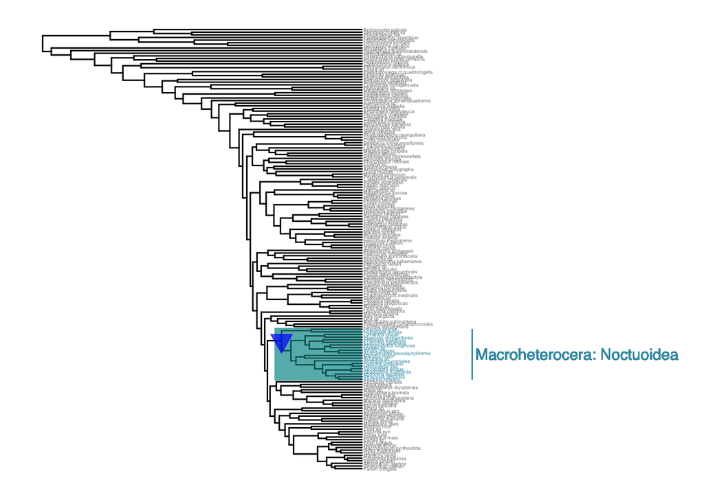

```
## # A tibble: 1 × 4
##       n rate.difference p.value clade
##   <dbl>           <dbl>   <dbl> <chr>
## 1   225        -0.00162   0.001 Macroheterocera: Noctuoidea
```

#### Forewing PC2

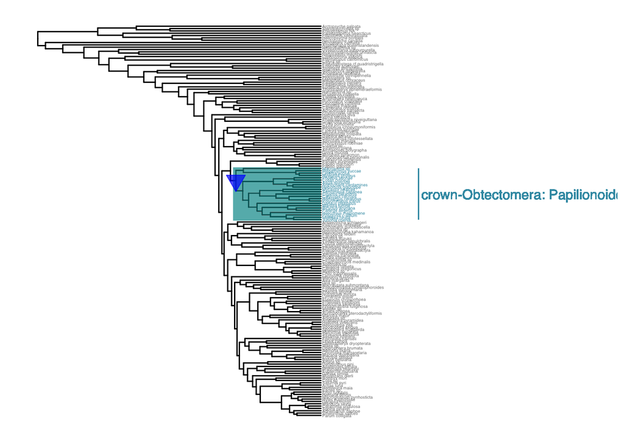

```
## # A tibble: 1 × 4
##       n rate.difference p.value clade
##   <dbl>           <dbl>   <dbl> <chr>
## 1   271        -0.00161   0.001 crown-Obtectomera: Papilionoidea
```

#### Hindwing PC1

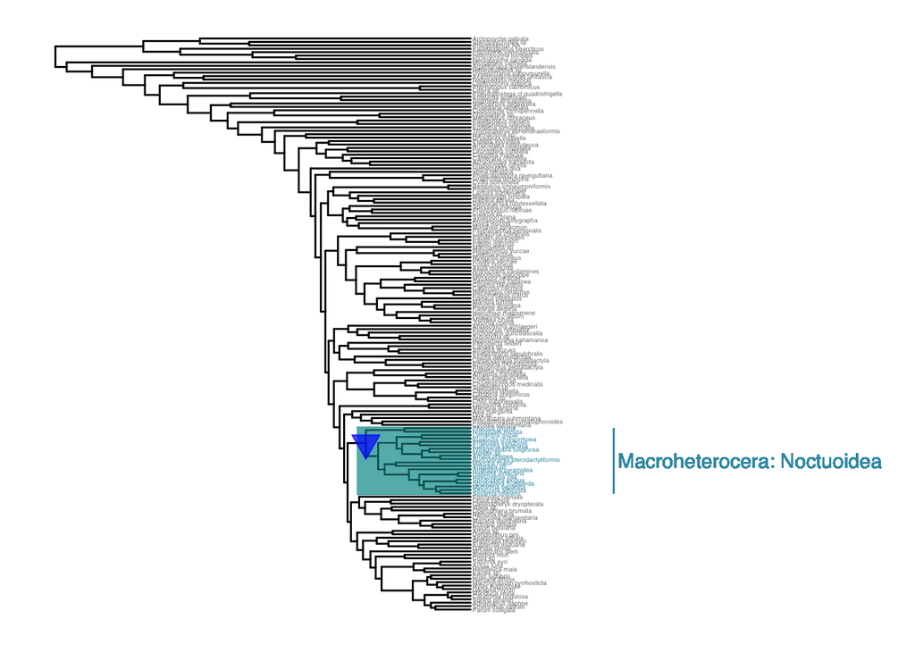

```
## # A tibble: 1 × 4
##       n rate.difference p.value clade
##   <dbl>           <dbl>   <dbl> <chr>
## 1   225        -0.00194   0.001 Macroheterocera: Noctuoidea
```

#### Hindwing PC2

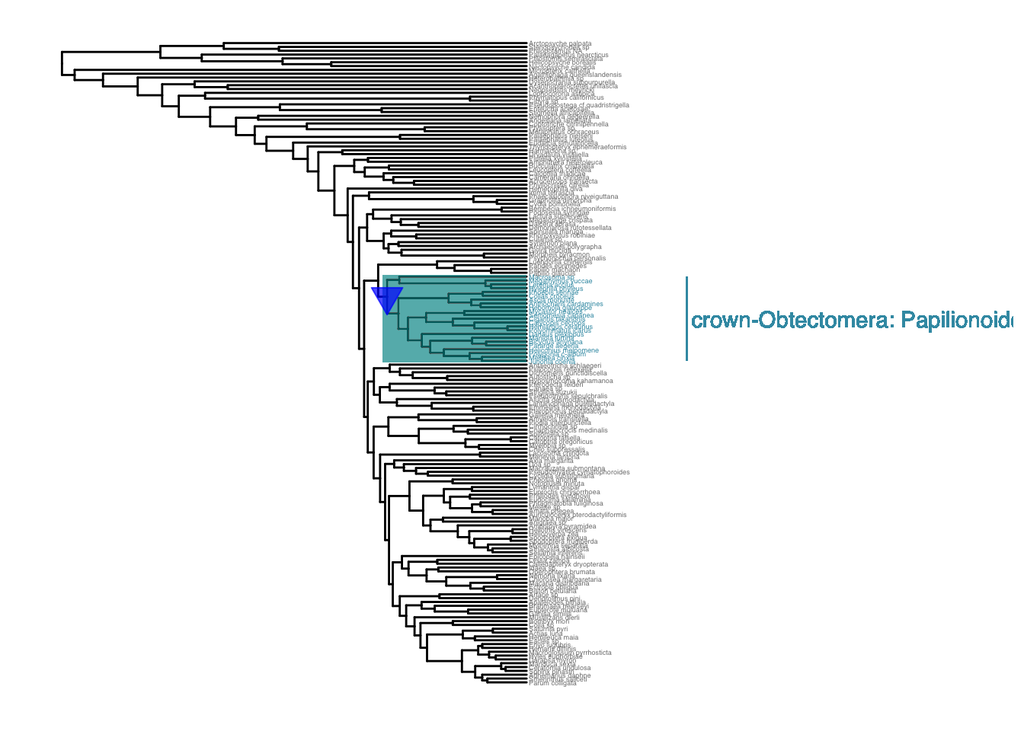

```
## # A tibble: 1 × 4
##       n rate.difference p.value clade
##   <dbl>           <dbl>   <dbl> <chr>
## 1   271        -0.00161   0.001 crown-Obtectomera: Papilionoidea
```

#### Shape Evolution Correlation

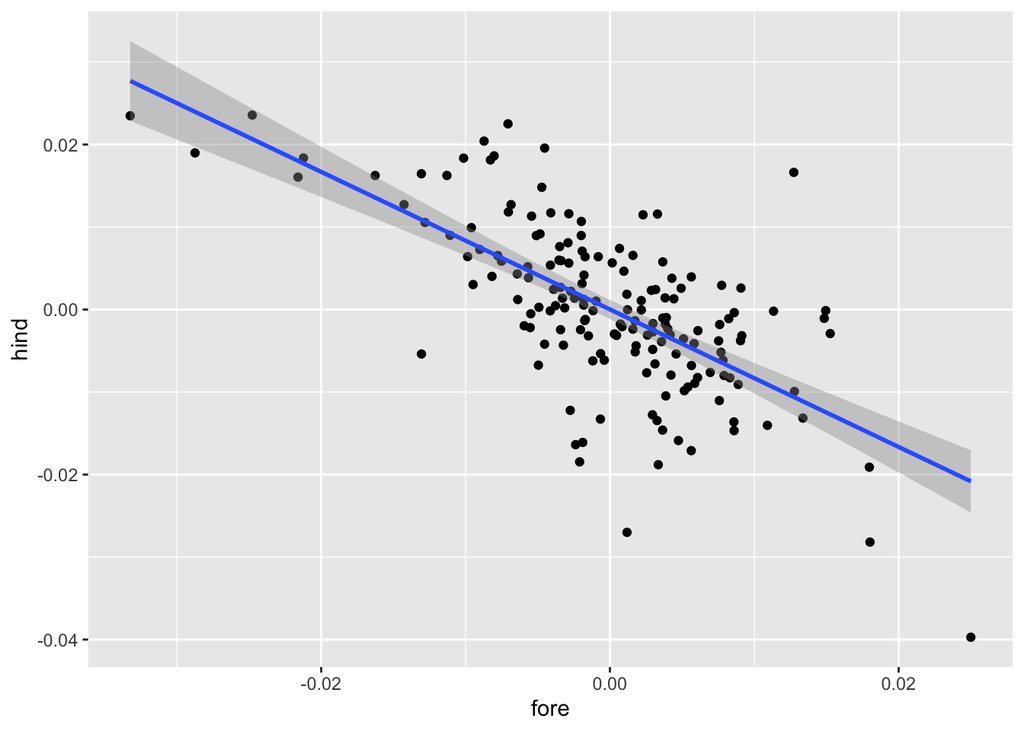

```r
hindPC1.pic <- pic(hind.pc1,phy = lep.tree2)
forePC1.pic <- pic(fore.pc1,phy = lep.tree2)
PC1.pic <- tibble(
  hind=hindPC1.pic,
  fore=forePC1.pic
)
PC1.pic %>%
  ggplot(aes(x=fore,y=hind))+geom_point()+geom_smooth(method="lm")
```

```r
summary(lm(hind~fore,PC1.pic))
```

```
##
## Call:
## lm(formula = hind ~ fore, data = PC1.pic)
##
## Residuals:
##        Min         1Q     Median         3Q        Max
## -0.0260329 -0.0040299 -0.0001764  0.0048320  0.0272273
##
## Coefficients:
##               Estimate Std. Error t value Pr(>|t|)
## (Intercept)  1.629e-05  5.845e-04   0.028    0.978
## fore        -8.335e-01  7.209e-02 -11.562   <2e-16 ***
## ---
## Signif. codes:  0 '***' 0.001 '**' 0.01 '*' 0.05 '.' 0.1 ' ' 1
##
## Residual standard error: 0.007552 on 165 degrees of freedom
## Multiple R-squared:  0.4476, Adjusted R-squared:  0.4442
## F-statistic: 133.7 on 1 and 165 DF,  p-value: < 2.2e-16
```

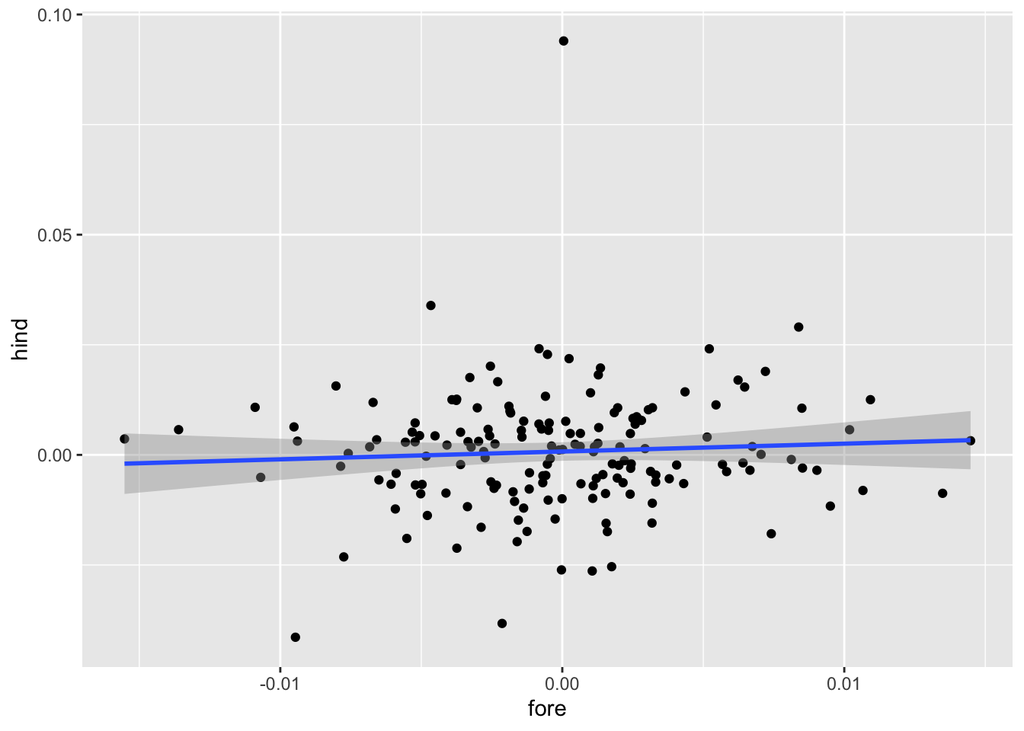

```r
hindPC2.pic <- pic(hind.pc2,phy = lep.tree2)
forePC2.pic <- pic(fore.pc2,phy = lep.tree2)
PC2.pic <- tibble(
  hind=hindPC2.pic,
  fore=forePC2.pic
)
PC2.pic %>%
  ggplot(aes(x=fore,y=hind))+geom_point()+geom_smooth(method="lm") #plot PIC PC2
```

```r
summary(lm(hind~fore,PC2.pic)) #Find R-square
```

```
##
## Call:
## lm(formula = hind ~ fore, data = PC2.pic)
##
## Residuals:
##       Min        1Q    Median        3Q       Max
## -0.040493 -0.007104  0.000357  0.006907  0.093219
##
## Coefficients:
##              Estimate Std. Error t value Pr(>|t|)
## (Intercept) 0.0007655  0.0010652   0.719    0.473
## fore        0.1778140  0.2162627   0.822    0.412
##
## Residual standard error: 0.01375 on 165 degrees of freedom
## Multiple R-squared:  0.00408,    Adjusted R-squared:  -0.001955
## F-statistic: 0.676 on 1 and 165 DF,  p-value: 0.4121
```

We need a narrative for the results.

```r
grade <- grade-3
```

### Discussion

Great discussion!

### Author Contributions

Rachel Z. (Introduction)

Rachel R. (Methods, Bibliography)

Jordan Nunes (Discussion)

Michael Britt (Results, Digitization)

Excellent work. Thanks for staying the course and producing a very fine analysis more reflective of graduate work. Please just remember to include all your data and some narrative to the results. Congrats to you all!

```r
print(grade)
```

```
## [1] 68
```

### Bibliography

Chazot, Nicolas, Stephen Panara, Nicolas Zilbermann, Patrick Blandin, Yann Le Poul, Raphaël Cornette, Marianne Elias, and Vincent Debat. 2016. “Morpho Morphometrics: Shared Ancestry and Selection Drive the Evolution of Wing Size and Shape in Morpho Butterflies.” *Evolution* 70 (1): 181–94.

Kawahara, Akito, David Plotkin, Marianne Espeland, Karen Meusemann, Emmanuel Toussaint, Alexander Donath, France Gimnich, et al. 2019. “Phylogenomics Reveals the Evolutionary Timing and Pattern of Butterflies and Moths.” *Proceedings of the National Academy of Sciences* 116 (October). https://doi.org/10.1073/pnas.1907847116.

Kratsch, Christina, and Alice McHardy. 2014. “RidgeRace: Ridge Regression for Continuous Ancestral Character Estimation on Phylogenetic Trees.” *Bioinformatics (Oxford, England)* 30 (September): i527–33. https://doi.org/10.1093/bioinformatics/btu477.

Le Roy, Camille, Vincent Debat, and Violaine Llaurens. 2019. “Adaptive Evolution of Butterfly Wing Shape: From Morphology to Behaviour.” *Biological Reviews* 94 (4): 1261–81.

O’Meara, Brian, Cécile Ané, Michael Sanderson, and Peter Wainwright. 2006. “Testing for Different Rates of Continuous Trait Evolution Using Likelihood.” *Evolution; International Journal of Organic Evolution* 60 (June): 922–33. https://doi.org/10.1554/05-130.1.

Owens, H L, D S Lewis, F L Condamine, A Y Kawahara, and R P Guralnick. 2020. “Comparative Phylogenetics of Papilio Butterfly Wing Shape and Size Demonstrates Independent Hindwing and Forewing Evolution.” *Systematic Biology* 69 (5): 813–19. https://doi.org/10.1093/sysbio/syaa029.

Owens, HL, DS Lewis, Fabien L Condamine, AY Kawahara, and RP Guralnick. 2020. “Comparative Phylogenetics of Papilio Butterfly Wing Shape and Size Demonstrates Independent Hindwing and Forewing Evolution.” *Systematic Biology* 69 (5): 813–19.